# Regresión Logística y Descenso de Gradiente

#### Lucía Piqueras Córcoles

*Noviembre 2020*

## Tabla de contenidos

- Objetivo
- Introducción
- 1. Carga de paquetes
- 2. Carga de datos
- 3. Visualización de los datos
- 4. Definición de la función sigmoidea logística
- 5. Cálculo de la función de coste y el gradiente
- 6. Coste y gradiente en la inicialización
- 7. Descenso de gradiente
- 8. Visualización de la convergencia
- 9. Referencias

## Objetivo

Con la siguiente práctica se pretende programar el descenso del gradiente con regresión logística, de manera manual, en base al archivo de datos `4_1_data.csv`.

[figure not shown]

## Introducción

El método de **optimización por descenso de gradiente** sigue un proceso iterativo en el que, partiendo de una posición inicial dentro del dominio de la función, realiza desplazamientos en la dirección correcta hasta alcanzar el mínimo. Para poder llevar a cabo el proceso se necesita:

- *La función objetivo a minimizar*: **(función de coste)**.
- *La posición desde la que iniciar la búsqueda*: (valores de inicialización).
- *La distancia* **(step o learning rate)** que se va a desplazar el algoritmo en cada iteración de búsqueda. Es importante escoger un learning rate adecuado en cada escenario. Si es muy pequeño, se tardará demasiado en llegar al mínimo y, si es demasiado grande, el algoritmo saltará de una región a otra pasando por encima del mínimo sin alcanzarlo.
- *La dirección de búsqueda* en la que se produce el desplazamiento. El algoritmo de descenso de gradiente se caracteriza porque emplea como dirección de búsqueda aquella en la que la función desciende en mayor medida. Esta dirección se corresponde con el valor negativo del gradiente de la función. **El gradiente de la función es el vector formado por las derivadas parciales de la función respecto a cada variable.**
- *La tolerancia*: Al tratarse de un algoritmo iterativo, hay que indicar una regla de parada. Lo idóneo es que el algoritmo se detenga al encontrar el mínimo, pero como normalmente se desconoce cuál es, hay que conseguir que se pare lo más cerca posible. Una forma de cuantificar la proximidad al mínimo es controlar cuanto desciende el valor de la función entre iteraciones consecutivas. **Si el descenso es muy pequeño, significa que se encuentra muy cerca del valor**. La tolerancia se define como un valor tal que, si la diferencia en el descenso es menor o igual, se considera que se ha alcanzado el mínimo (el algoritmo converge). Una alternativa a calcular la distancia entre las dos iteraciones es medir la longitud del vector gradiente en cada iteración. Si su longitud es muy pequeña, también lo es la distancia al mínimo.
- *Iteraciones máximas*: Si la posición de inicio en la búsqueda está muy alejada del mínimo de la función y el learning rate es muy pequeño, se pueden necesitar muchas iteraciones para alcanzarlo. Para evitar un proceso iterativo excesivamente largo, se suele establecer un número máximo de iteraciones permitidas.

## 1. Carga de paquetes

```python
import numpy as np
import pandas as pd
import seaborn as sns
import matplotlib.pyplot as plt
%matplotlib inline
```

## 2. Carga de datos

```python
file_path = ("../data/raw/4_1_data.csv")
```

```python
data = pd.read_csv(file_path)
data
```

|  | score-1 | score-2 | label |
| --- | --- | --- | --- |
| 0 | 34.623660 | 78.024693 | 0 |
| 1 | 30.286711 | 43.894998 | 0 |
| 2 | 35.847409 | 72.902198 | 0 |
| 3 | 60.182599 | 86.308552 | 1 |
| 4 | 79.032736 | 75.344376 | 1 |
| ... | ... | ... | ... |
| 95 | 83.489163 | 48.380286 | 1 |
| 96 | 42.261701 | 87.103851 | 1 |
| 97 | 99.315009 | 68.775409 | 1 |
| 98 | 55.340018 | 64.931938 | 1 |
| 99 | 74.775893 | 89.529813 | 1 |

100 rows × 3 columns

Viendo las columnas, tiene sentido pensar que el conjunto de datos hace referencia a las notas obtenidas por diferentes alumnos en dos examenes de una asignatura (por ejemplo), así como a su resultado final en la asignatura (label), variable binaria que indica si el alumno ha aprobado(1) o suspendido(0), en función de las notas e cada observación.

También, siguiendo el ejemplo visto en clase, podemos decir que somos el administrador de una universidad y queremos saber las posibilidades de admisión de cada solicitante en función de dos exámenes. En este caso, las dos columnas de `scores` son la puntuación de dos exámenes de solicitantes anteriores y `label` indica si el solicitante obtuvo la admisión o no (1 - si obtuvo la admisión 0 - en caso contrario).

- Contamos con los datos históricos de solicitantes anteriores que se pueden utilizar como datos de entrenamiento para la regresión logística.

```python
data.info()
```

```
<class 'pandas.core.frame.DataFrame'>
RangeIndex: 100 entries, 0 to 99
Data columns (total 3 columns):
 #   Column   Non-Null Count  Dtype
---  ------   --------------  -----
 0   score-1  100 non-null    float64
 1   score-2  100 non-null    float64
 2   label    100 non-null    int64
dtypes: float64(2), int64(1)
memory usage: 2.5 KB
```

Comprobamos que las tres variables son de tipo numérico, las dos primeras son con decimales y la última de tipo entero binario (valores 0 y 1).

## 3. Visualización de los datos

Como se ha comentado, la idea es optimizar la función de coste mediante regresión logística y descenso de gradiente. Visualizamos los dos tipos de situaciones que tenemos, los que obtuvieron la admisión y los que no.

Antes de nada, guardo las dos columnas con los datos de las calificaciones en el objeto `notas` y lo mismo con los resultados.

```python
notas = data[['score-1', 'score-2']].values
resultado = data['label'].values
```

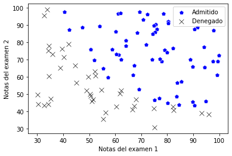

```python
# Indico qué es suspenso y qué es aprobado
# Con 100 y 1 definimos el tamaño de ambos conjuntos:
admitido = (resultado == 1).reshape(100, 1)
rechazado = (resultado == 0).reshape(100, 1)

# definimos los ejes de los plots tanto para las notas aprobadas como suspensas de ambas columnas:

ax = sns.scatterplot(x = notas[admitido[:, 0], 0], # x las notas aprobadas de la columna 1
                     y = notas[admitido[:, 0], 1], # y las notas aprobadas de la columna 2
                     marker = "p", # definimos los parámetros del marker (forma, color y tamaño)
                     color = "blue",
                     s = 60)
sns.scatterplot(x = notas[rechazado[:, 0], 0], # notas suspensas de la columna 1
                y = notas[rechazado[:, 0], 1], # notas suspensas de la columna 2
                marker = "x", # definimos los parámetros del marker (forma, color y tamaño)
                color = "black",
                s = 60)

ax.set(xlabel="Notas del examen 1", ylabel="Notas del examen 2")
ax.legend(["Admitido", "Denegado"])
plt.show();
```

En este caso, tenemos dos variables predictoras (puntuaciones de dos exámenes) y `label` como variable de respuesta. La ecuación es la siguiente:

ŷ = σ (w1x1 + w2x2 + b)

Recordamos que queremos encontrar la w y b que **minimicen la función de coste**, no la función ŷ de probabilidad.

## 4. Definición de la función sigmoidea logística

Para implementar la regresión logística y poder entrenar un modelo que encuentre el límite de decisión óptimo que nos permita hacer una predicción futura, el primer paso es crear la **función sigmoidea**.

Simplemente escibo a mano su función matemática:

```python
def funcion_logistica(x):
    return 1/ (1 + np.exp(-x))
```

```python
funcion_logistica(0)
```

```
0.5
```

La función sigmoidea es una curva en forma de S que puede tomar cualquier número de valor real y asignar a un valor entre 0 y 1. La interpretación del resultado puede tomarse como la probabilidad de que el ejemplo de entrada se clasifique positivamente.

## 5. Cálculo de la Función de Coste y el Gradiente

Minimizar la Función de Coste significa encontrar el valor óptimo o más bajo de theta y es para esto para lo que utilizamos el algoritmo de *Gradient Descent*:

Consideremos que `m` es el número de training set (set de entrenamiento), `x` son las variables de entrada e `y` las variables a predecir.

```python
# traducimos tal cual las funciones matemáticas a lenguaje python:
def funcion_coste(theta, x, y):
    m = len(y)  # número de observaciones
    y_pred = funcion_logistica(np.dot(x , theta))  # sigma(h^0 * x)
    error = (y * np.log(y_pred)) + ((1 - y) * np.log(1 - y_pred)) # la fórmula de la función de error
    cost = -1 / m * sum(error) # coste = -1/m multiplicado por el sumatorio del error
    gradient = 1 / m * np.dot(x.transpose(), (y_pred - y)) #
    return cost[0] , gradient
```

El resultado será la suma del "error" como la diferencia entre la probabilidad asignada por el modelo y lo que ocurre en realidad.

## 6. Inicialización

Para ayudar a que el logaritmo de descenso de gradiente converja antes, aplicaremos la **normalización de las notas** como *scaling method*.

```python
# Normalizamos las notas:
media_notas = np.mean(notas, axis=0) # media de los resultados del examen
std_notas = np.std(notas, axis=0)  # desviacion típica de los resultados
notas = (notas - media_notas) / std_notas

filas = notas.shape[0] # nº filas
columnas = notas.shape[1] # nº columns

X = np.append(np.ones((filas, 1)), notas, axis=1) # añadimos término independiente compuesto por 1's
y = resultado.reshape(filas, 1) # array con 0's y 1's. Resultado como matriz

theta_init = np.zeros((columnas + 1, 1)) #  parametros iniciales.
cost, gradient = funcion_coste(theta_init, X, y) # coste con el theta inicial

print("Coste en la inicialización", cost) # para que nos devuelva el coste (en la inicialización)
print("Gradiente en la inicialización:", gradient) # para que nos devuelva la gradiente (en la inicialización)
```

```
Coste en la inicialización 0.693147180559946
Gradiente en la inicialización: [[-0.1       ]
 [-0.28122914]
 [-0.25098615]]
```

Vemos que el Coste inicial es de 0.69 y que Gradiente en la inicialización es de [[-0.1 ][-0.28122914][-0.25098615]].

## 7. Descenso de gradiente

Definimos la función de Descenso de Gradiente. Para ello, minimizamos la función de coste actualizando la ecuación tantas veces sea necesario hasta alcanzar la convergencia:

```python
# la función de descenso de gradiente está compuesta, a parte de x e y, por theta, alpha (tasa de aprendizaje) y el nº de iteraciones
def descenso_gradiente(x, y, theta, alpha, iterations):
    costs = [] # el que ocurra en cada caso
    for i in range(iterations): # hacemos un for para que itere todos los datos y actualice la ecuación
        cost, gradient = funcion_coste(theta, x, y) # el coste se reduce conforme va bajando
        theta -= (alpha * gradient) # quitamos theta y multiplicamos la tasa de aprendizaje por el gradiente
        costs.append(cost)
    return theta, costs
```

Podemos inicializar theta y el coste con una tasa de aprendizaje de 1 y 200 iteraciones:

```python
theta, costs = descenso_gradiente(X, y, theta_init, 1, 200)
```

```python
print("Theta tras ejecutar el descenso de gradiente:", theta)
print("Coste resultante:", costs[-1])
```

```
Theta tras ejecutar el descenso de gradiente: [[1.50850586]
 [3.5468762 ]
 [3.29383709]]
Coste resultante: 0.20489382036036602
```

Vemos como han cambiado ambos resultados desde la inicialización de los parámetros Siendo el coste bastante más bajo ( 0.20489382036036602).

## 8. Visualización de la convergencia de la Función de Coste

Visualizamos el paso anterior

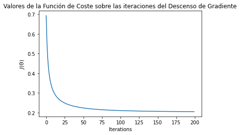

```python
plt.plot(costs) # usando matplotlib
plt.xlabel("Iterations")
plt.ylabel("$J(\Theta)$")
plt.title("Valores de la Función de Coste sobre las iteraciones del Descenso de Gradiente");
```

Vemos como el error cae desde el valor de inicialización 0.69 hasta 0.20, con una tasa de aprendizaje de 1 (alta) y pocas iteraciones (200).

- Probamos con más iteraciones, y una tasa de aprendizaje menor:

```python
theta, costs = descenso_gradiente(X, y, theta_init, 0.70, 1000)
```

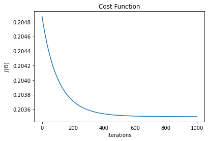

```python
plt.plot(costs)
plt.xlabel("Iterations")
plt.ylabel("$J(\Theta)$")
plt.title("Cost Function");
```

Puede verse que **el error continúa cayendo pero mínimamente**. Como comentamos al inicio, esto en principio, implica que **el mínimo está cerca**, ya que el descenso en cada iteración es muy pequeño.

Pruebo una vez más, para ver si se llega a algo menor:

```python
theta, costs = descenso_gradiente(X, y, theta_init, 0.8, 200)
```

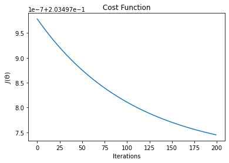

```python
plt.plot(costs)
plt.xlabel("Iterations")
plt.ylabel("$J(\Theta)$")
plt.title("Cost Function");
```

**Conclusión**

Probando con varias tasas de aprendizaje y con varias iteraciones (aunque sólo parezca una graficada), se ha comprobado que ya no merece la pena continuar, habiendo por lo tanto, encontrado el mínimo de esta función en torno a 0.2.

Como último paso, realizaré la prediccion con el valor óptimo de la función de coste que hemos obtenido:

## 9. Predicción utilizando los valores óptimos obtenidos de la Función de Coste

```python
def prediccion(theta, x):
    resultado = x.dot(theta)
    return resultado > 0
```

```python
p = prediccion(theta, X)
print("Accuracy del entrenamiento:", sum(p==y)[0],"%")
```

```
Accuracy del entrenamiento: 89 %
```

Obtenemos un accuracy del 89%, lo cual está bastante bien.

Aplicamos a un caso, para ver la probabilidad que tendría un alumno de ser aceptado:

```python
test = np.array([50,79]) # una list formada por dos notas
test = (test - media_notas)/std_notas
# el resultado del test es las notas obenidas - media de las notas, entre la desviación típica
test = np.append(np.ones(1), test)
probability = funcion_logistica(test.dot(theta))
print("Una persona con notas de 50 y 79 en los test tendrá una probabilidad de ser admitido del",
      np.round(probability[0], 2))
```

```
Una persona con notas de 50 y 79 en los test tendrá una probabilidad de ser admitido del 0.74
```

#### Referencias

- https://www.cienciadedatos.net/documentos/27_regresion_logistica_simple_y_multiple#Anexos
- https://github.com/lmntrixsid/Linear-and-Logistic-Regression-with-NumPy-and-Python/blob/master/Logistic_Regression_Completed.ipynb
- https://www.coursera.org/lecture/deteccion-objetos/l2-4-b-regresion-logistica-aprendizaje-ii-b68uj